# 4

2023-04-06

## 4 Mixture Models

```r
## -----------------------------------------------------------------------------
coinflips = (runif(10000) > 0.5)
table(coinflips)
```

```
## coinflips
## FALSE  TRUE
##  4979  5021
```

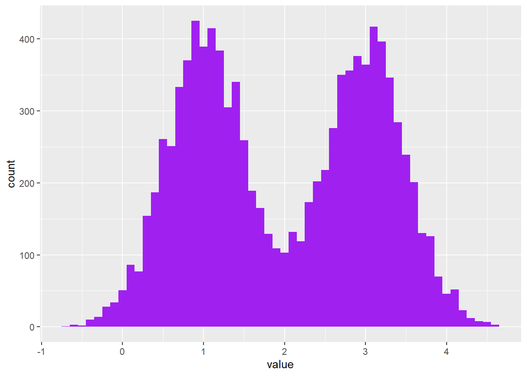

```r
oneFlip = function(fl, mean1 = 1, mean2 = 3, sd1 = 0.5, sd2 = 0.5) {
  if (fl) {
   rnorm(1, mean1, sd1)
  } else {
   rnorm(1, mean2, sd2)
  }
}
fairmix = vapply(coinflips, oneFlip, numeric(1))
library("ggplot2")
library("dplyr")
ggplot(tibble(value = fairmix), aes(x = value)) +
     geom_histogram(fill = "purple", binwidth = 0.1)
```

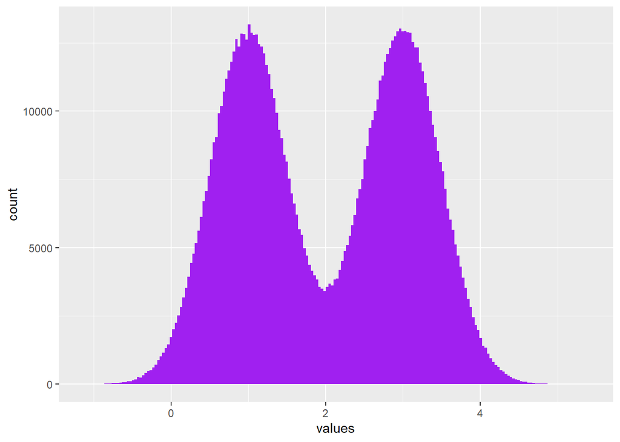

```r
## -----------------------------------------------------------------------------
means = c(1, 3)
sds   = c(0.5, 0.5)
values = rnorm(length(coinflips),
               mean = ifelse(coinflips, means[1], means[2]),
               sd   = ifelse(coinflips, sds[1],   sds[2]))



## -----------------------------------------------------------------------------
fair = tibble(
  coinflips = (runif(1e6) > 0.5),
  values = rnorm(length(coinflips),
                 mean = ifelse(coinflips, means[1], means[2]),
                 sd   = ifelse(coinflips, sds[1],   sds[2])))
ggplot(fair, aes(x = values)) +
     geom_histogram(fill = "purple", bins = 200)
```

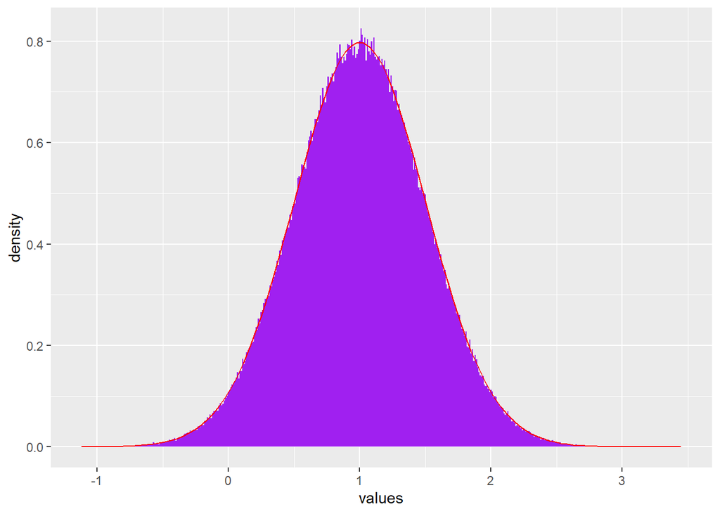

```r
## -----------------------------------------------------------------------------
ggplot(dplyr::filter(fair, coinflips), aes(x = values)) +
  geom_histogram(aes(y = after_stat(density)), fill = "purple", binwidth = 0.01) +
  stat_function(fun = dnorm, color = "red",
                args = list(mean = means[1], sd = sds[1]))
```

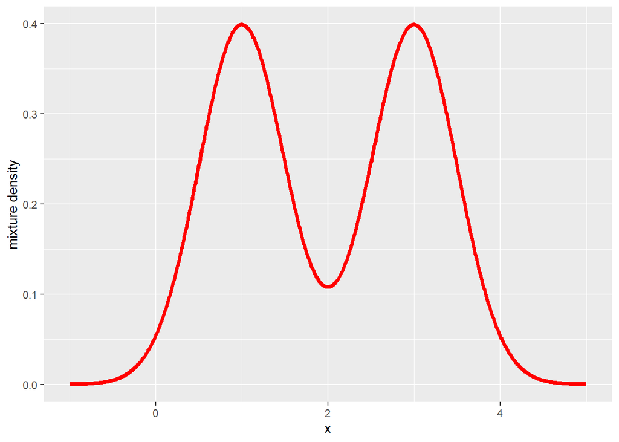

```r
## -----------------------------------------------------------------------------
fairtheory = tibble(
  x = seq(-1, 5, length.out = 1000),
  f = 0.5 * dnorm(x, mean = means[1], sd = sds[1]) +
      0.5 * dnorm(x, mean = means[2], sd = sds[2]))
ggplot(fairtheory, aes(x = x, y = f)) +
  geom_line(color = "red", linewidth = 1.5) + ylab("mixture density")
```

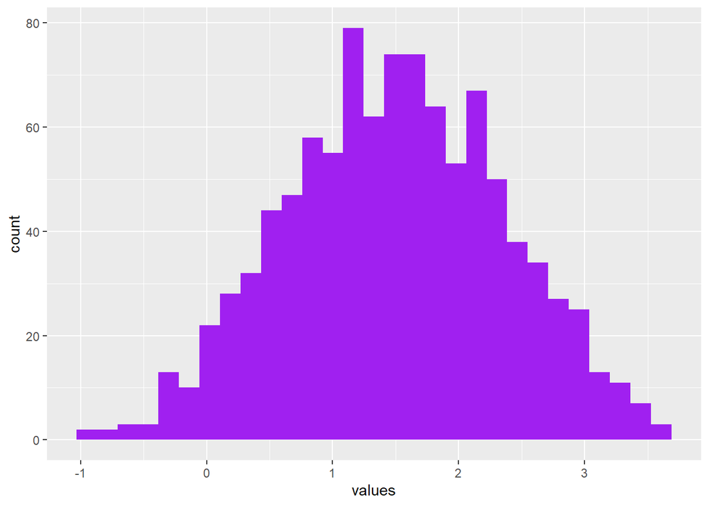

```r
## -----------------------------------------------------------------------------
mystery = tibble(
  coinflips = (runif(1e3) > 0.5),
  values = rnorm(length(coinflips),
                 mean = ifelse(coinflips, 1, 2),
                 sd   = ifelse(coinflips, sqrt(.5), sqrt(.5))))
br2 = with(mystery, seq(min(values), max(values), length.out = 30))
ggplot(mystery, aes(x = values)) +
geom_histogram(fill = "purple", breaks = br2)
```

```r
## -----------------------------------------------------------------------------
head(mystery, 3)
```

```
## # A tibble: 3 × 2
##   coinflips values
##   <lgl>      <dbl>
## 1 FALSE       1.06
## 2 FALSE       1.17
## 3 FALSE       2.24
```

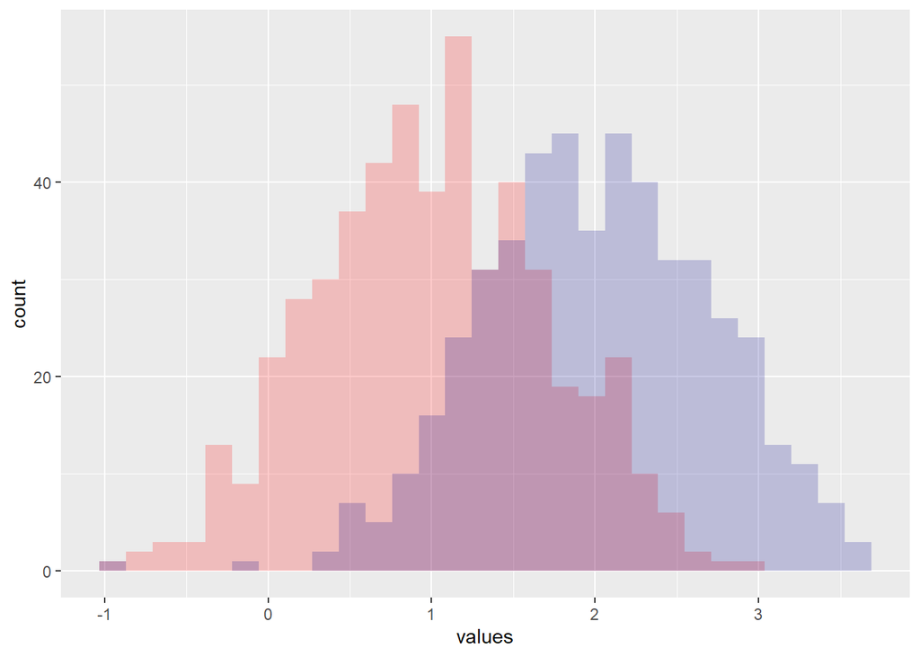

```r
br = with(mystery, seq(min(values), max(values), length.out = 30))
ggplot(mystery, aes(x = values)) +
  geom_histogram(data = dplyr::filter(mystery, coinflips),
     fill = "red", alpha = 0.2, breaks = br) +
  geom_histogram(data = dplyr::filter(mystery, !coinflips),
     fill = "darkblue", alpha = 0.2, breaks = br)
```

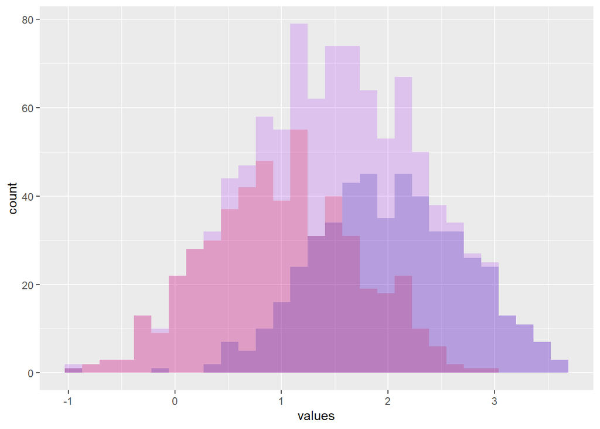

```r
## -----------------------------------------------------------------------------
stopifnot(identical(br2, br))

## -----------------------------------------------------------------------------
ggplot(mystery, aes(x = values, fill = coinflips)) +
  geom_histogram(data = dplyr::filter(mystery, coinflips),
     fill = "red", alpha = 0.2, breaks = br) +
  geom_histogram(data = dplyr::filter(mystery, !coinflips),
     fill = "darkblue", alpha = 0.2, breaks = br) +
  geom_histogram(fill = "purple", breaks = br, alpha = 0.2)
```

```r
## -----------------------------------------------------------------------------
mus = c(-0.5, 1.5)
lambda = 0.5
u = sample(2, size = 100, replace = TRUE, prob = c(lambda, 1-lambda))
x = rnorm(length(u), mean = mus[u])
dux = tibble(u, x)
head(dux)
```

```
## # A tibble: 6 × 2
##       u      x
##   <int>  <dbl>
## 1     1  0.441
## 2     1 -0.788
## 3     2  2.31
## 4     2  2.33
## 5     1 -1.12
## 6     2  2.71
```

```r
## -----------------------------------------------------------------------------
group_by(dux, u) |> summarise(mu = mean(x), sigma = sd(x))
```

```
## # A tibble: 2 × 3
##       u     mu sigma
##   <int>  <dbl> <dbl>
## 1     1 -0.561  1.09
## 2     2  1.41   1.03
```

```r
table(dux$u) / nrow(dux)
```

```
##
##    1    2
## 0.43 0.57
```

```r
## -----------------------------------------------------------------------------
.o = options(digits = 3)
library("mixtools")
y = c(rnorm(100, mean = -0.2, sd = 0.5),
      rnorm( 50, mean =  0.5, sd =   1))
gm = normalmixEM(y, k = 2,
                    lambda = c(0.5, 0.5),
                    mu = c(-0.01, 0.01),
                    sigma = c(3, 3))
```

```
## number of iterations= 171
```

```r
with(gm, c(lambda, mu, sigma, loglik))
```

```
## [1]    0.842    0.158   -0.112    0.692    0.579    1.050 -161.018
```

```r
options(.o)
```

```r
gm$lambda
```

```
## [1] 0.8418547 0.1581453
```

```r
## -----------------------------------------------------------------------------
## PROVENANCE: here's a record of how the data were created
library("mosaics")
library("mosaicsExample")
for(f in c("wgEncodeSydhTfbsGm12878Stat1StdAlnRep1_chr22_sorted.bam",
           "wgEncodeSydhTfbsGm12878InputStdAlnRep1_chr22_sorted.bam"))
  constructBins(infile = system.file(file.path("extdata", f), package="mosaicsExample"),
    fileFormat = "bam", outfileLoc = "../data/",
    byChr = FALSE, useChrfile = FALSE, chrfile = NULL, excludeChr = NULL,
    PET = FALSE, fragLen = 200, binSize = 200, capping = 0)
```

[output not shown]

```
## Use the provided BAM index file.
```

```
## Chromosome information is extracted from the BAM file.
```

```
## Info: reading the aligned read file and processing it into bin-level files...
```

```
## Info: done!
```

[output not shown]

```
## Use the provided BAM index file.
```

```
## Chromosome information is extracted from the BAM file.
```

```
## Info: reading the aligned read file and processing it into bin-level files...
```

```
## Info: done!
```

```
## ------------------------------------------------------------
## Info: processing summary
## ------------------------------------------------------------
## Directory of processed bin-level files: ../data/
## Processed bin-level file: wgEncodeSydhTfbsGm12878InputStdAlnRep1_chr22_sorted.bam_fragL200_bin200.txt
## Sequencing depth: 182605
## ------------------------------------------------------------
```

```r
datafiles = c("../data/wgEncodeSydhTfbsGm12878Stat1StdAlnRep1_chr22_sorted.bam_fragL200_bin200.txt",
              "../data/wgEncodeSydhTfbsGm12878InputStdAlnRep1_chr22_sorted.bam_fragL200_bin200.txt")
binTFBS = readBins(type = c("chip", "input"), fileName = datafiles)
```

```
## Info: reading and preprocessing bin-level data...
```

```
## Info: data contains only one chromosome.
```

```
## Info: done!
```

```r
## -----------------------------------------------------------------------------
binTFBS
```

```
## Summary: bin-level data (class: BinData)
## ----------------------------------------
## - # of chromosomes in the data: 1
## - total effective tag counts: 462479
##   (sum of ChIP tag counts of all bins)
## - control sample is incorporated
## - mappability score is NOT incorporated
## - GC content score is NOT incorporated
## - uni-reads are assumed
## ----------------------------------------
```

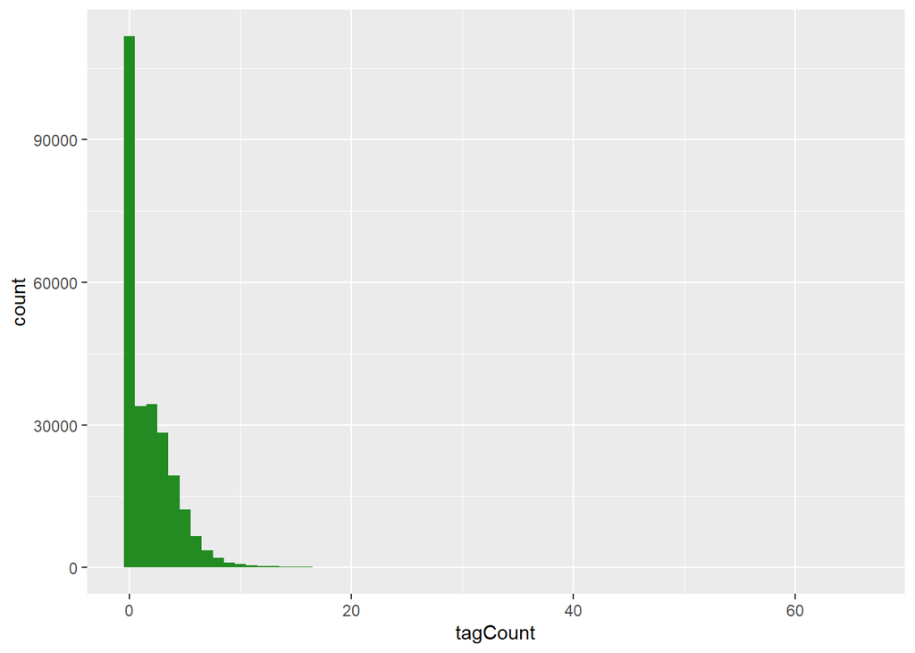

```r
## -----------------------------------------------------------------------------
bincts = print(binTFBS)
ggplot(bincts, aes(x = tagCount)) +
  geom_histogram(binwidth = 1, fill = "forestgreen")
```

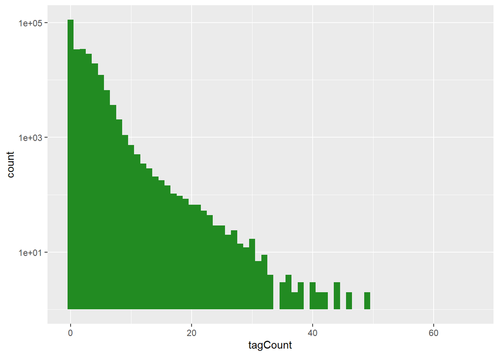

```r
## -----------------------------------------------------------------------------
ggplot(bincts, aes(x = tagCount)) + scale_y_log10() +
   geom_histogram(binwidth = 1, fill = "forestgreen")
```

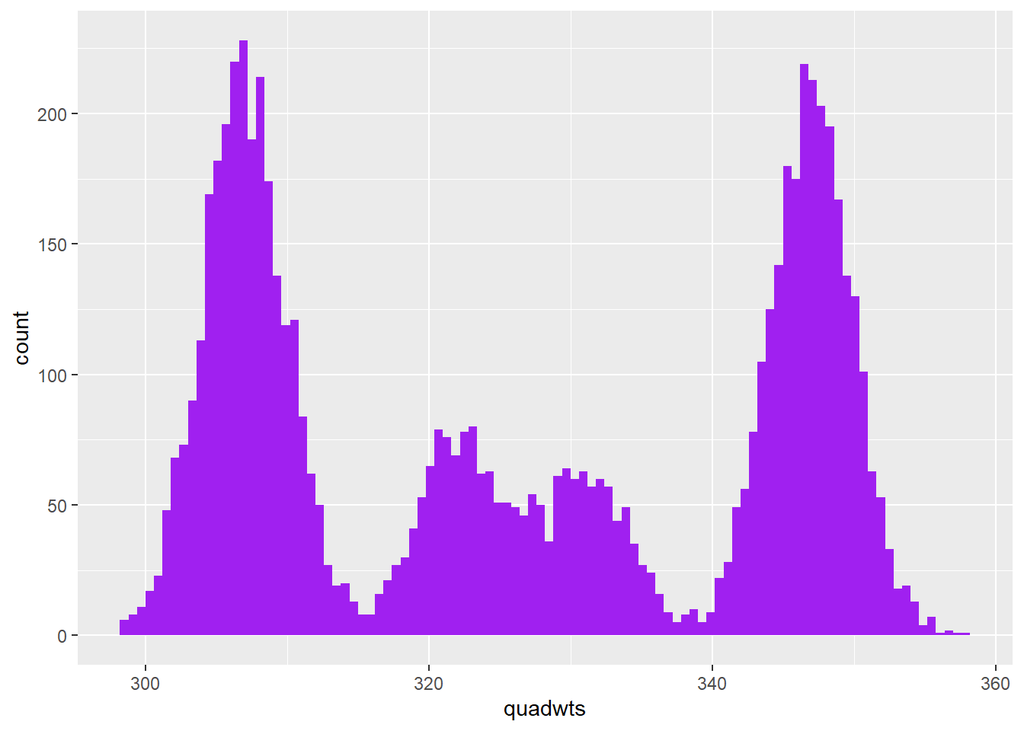

```r
## -----------------------------------------------------------------------------
masses = c(A =  331, C =  307, G =  347, T =  322)
probs  = c(A = 0.12, C = 0.38, G = 0.36, T = 0.14)
N  = 7000
sd = 3
nuclt   = sample(length(probs), N, replace = TRUE, prob = probs)
quadwts = rnorm(length(nuclt),
                mean = masses[nuclt],
                sd   = sd)
ggplot(tibble(quadwts = quadwts), aes(x = quadwts)) +
  geom_histogram(bins = 100, fill = "purple")
```

```r
## -----------------------------------------------------------------------------
library("HistData")
ZeaMays$diff
```

```
##  [1]  6.125 -8.375  1.000  2.000  0.750  2.875  3.500  5.125  1.750  3.625
## [11]  7.000  3.000  9.375  7.500 -6.000
```

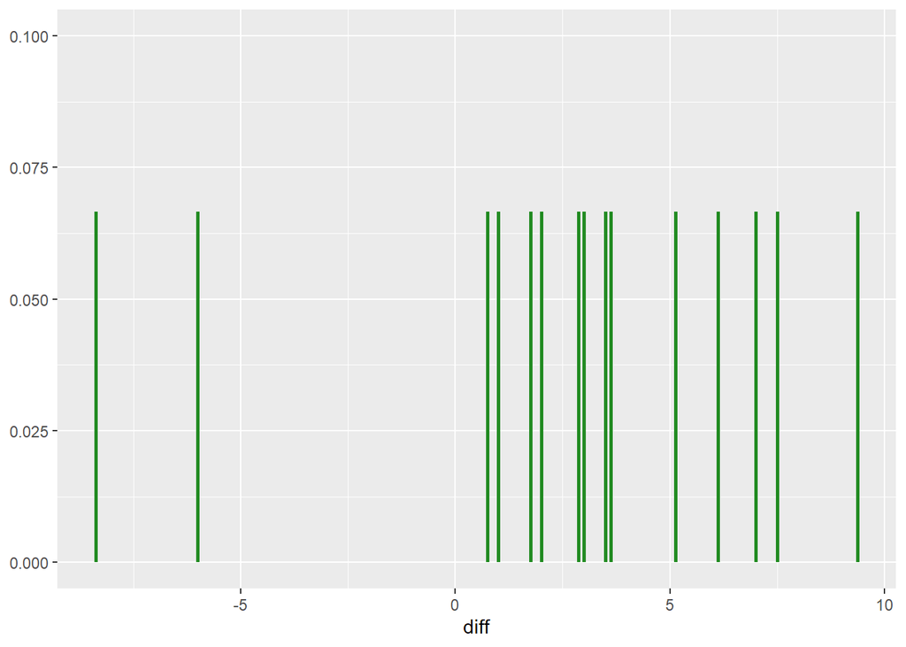

```r
ggplot(ZeaMays, aes(x = diff, ymax = 1/15, ymin = 0)) +
  geom_linerange(linewidth = 1, col = "forestgreen") + ylim(0, 0.1)
```

```r
## -----------------------------------------------------------------------------
stopifnot(nrow(ZeaMays) == 15)
```

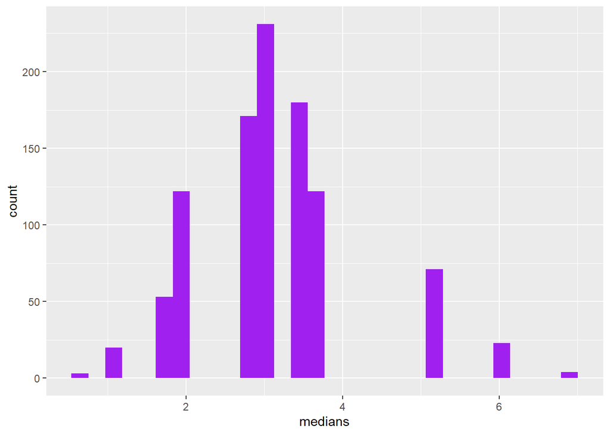

```r
## -----------------------------------------------------------------------------
B = 1000
meds = replicate(B, {
  i = sample(15, 15, replace = TRUE)
  median(ZeaMays$diff[i])
})
ggplot(tibble(medians = meds), aes(x = medians)) +
  geom_histogram(bins = 30, fill = "purple")
```

```r
## -----------------------------------------------------------------------------
library("bootstrap")
bootstrap(ZeaMays$diff, B, mean)
```

[output not shown]

[output cut: 165 more lines]

```r
bootstrap(ZeaMays$diff, B, median)
```

[output not shown]

[output cut: 82 more lines]

> Laplace distribution

Probability density function :

$$f(x\mid \mu ,b)={\frac {1}{2b}}\exp
\left(-{\frac {|x-\mu |}{b}}\right)\,\!$$

Laplace is a function of normal and exponential random variables:

$$X=\sqrt{W}\cdot Z, \quad W\sim Exp(1),
\quad Z\sim N(0,1)$$
The Laplace distribution with mean $\mu \in \mathbb{R}$ and scale $b > 0$ has the probability density function
$$f_X(x)=\frac{1}{2b}\exp\left(-\frac{\left|x\right|}{b}\right)$$
Note that if we can show that the Laplace distribution with mean $0$ is a mixture of normals, then by shifting all these normals by $\mu$, it follows that the Laplace distribution with mean $\mu$ is also a mixture of normals.

Fix $b > 0$. Let $W \sim \text{Exp}(\frac{1}{2b^2})$, i.e.
$$f_W(w) = \dfrac{1}{2b^2} \exp
\left(-\dfrac{x}{2b^2} \right)$$
for $w \geq 0$, and let $X \mid W = w \sim \mathcal{N}(0, w)$. We claim that $X$ has the Laplace distribution with mean $0$ and scale $b$. This is equivalent to showing that for any $x$,
$$\begin{align}
f_X(x)=\frac{1}{2b}\exp\left(-\frac{\left|x\right|}{b}\right)
\iff
\int_{0}^{\infty} f_{X\mid W=w}(x)f_{W}(w)dw =
\frac{1}{2b}\exp\left(-\frac{\left|x\right|}{b}\right)
\end{align}$$
$$\begin{align}
\int_{0}^{\infty} f_{X\mid W=w}(x)f_{W}(w)dw &= \int_{0}^{\infty}
\frac{1}{\sqrt{2\pi
w}}\exp\left(-\frac{x^2}{2w}\right)\frac{1}{2b^2}\exp\left(-\frac{w}{2b^2}\right)dw\\
&= \frac{1}{2b^2}\int_{0}^{\infty}\frac{1}{\sqrt{2\pi
w}}\exp\left(-\frac{w^2+x^2b^2}{2b^2w}\right)dw\\
&= \frac{1}{2b^2}\int_{0}^{\infty}\frac{1}{\sqrt{2\pi
w}}\exp\left(-\frac{(w-|x|b)^2}{2b^2w}-\frac{2w|x|b}{2b^2w}\right)dw\\
&= \frac{1}{2b^2}e^{-|x|/b}\int_{0}^{\infty}\frac{b}{\sqrt{2\pi b^2
w}}\exp\left(-\frac{(w-|x|b)^2}{2b^2w}\right)dw\\
&=\frac{1}{2b}\exp\left(-\frac{\left|x\right|}{b}\right)
\end{align}$$

The Mean of
$$\frac{1}{2b}\exp\left(-\frac{\left|x-\mu\right|}{b}\right)$$
is $\mu$ and Variance is $2b^2$.

```r
## -----------------------------------------------------------------------------
c(N3 = choose(5, 3), N15 = choose(29, 15))
```

```
##       N3      N15
##       10 77558760
```

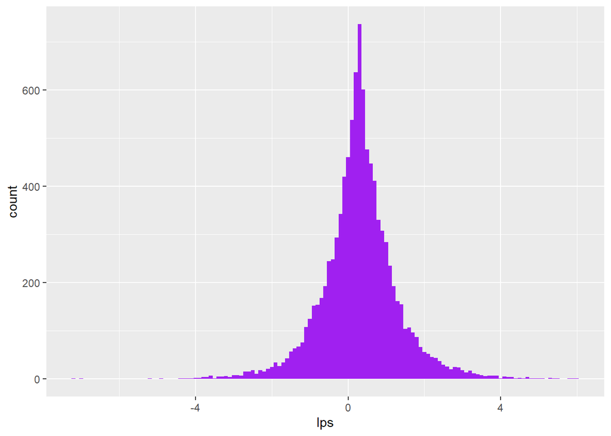

```r
## -----------------------------------------------------------------------------
w = rexp(10000, rate = 1)

## -----------------------------------------------------------------------------
mu  = 0.3
lps = rnorm(length(w), mean = mu, sd = sqrt(w))
ggplot(data.frame(lps), aes(x = lps)) +
  geom_histogram(fill = "purple", binwidth = 0.1)
```

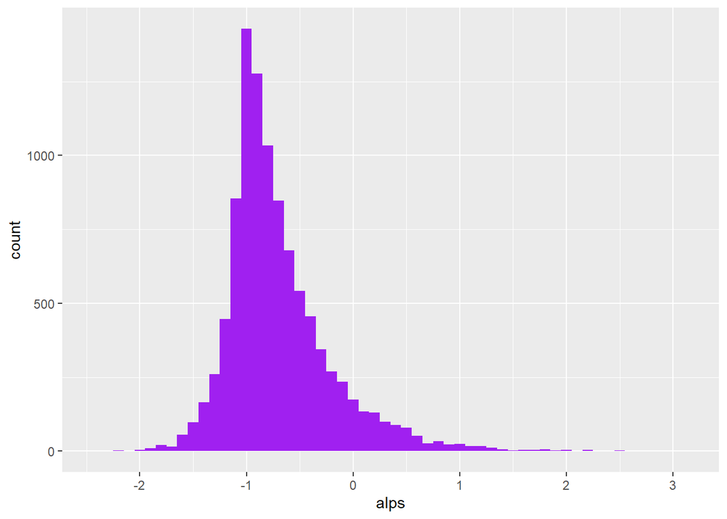

```r
## -----------------------------------------------------------------------------
mu = 0.3; sigma = 0.4; theta = -1
w  = rexp(10000, 1)
alps = rnorm(length(w), theta + mu * w, sigma * sqrt(w))
ggplot(tibble(alps), aes(x = alps)) +
  geom_histogram(fill = "purple", binwidth = 0.1)
```

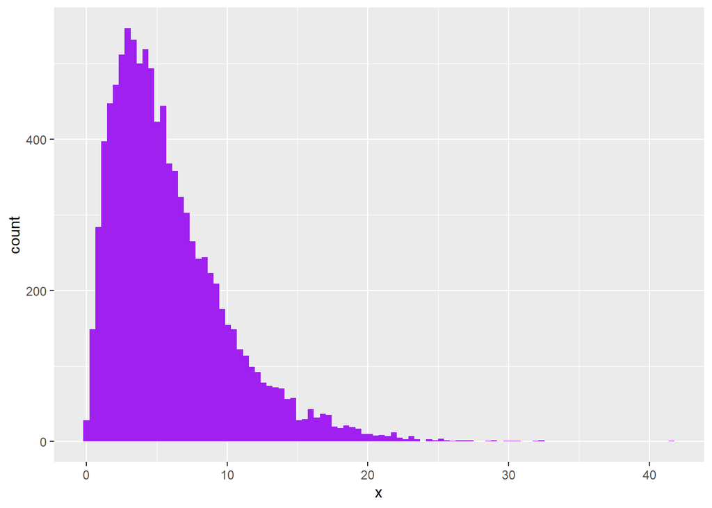

```r
## -----------------------------------------------------------------------------
ggplot(tibble(x = rgamma(10000, shape = 2, rate = 1/3)),
   aes(x = x)) + geom_histogram(bins = 100, fill= "purple")
```

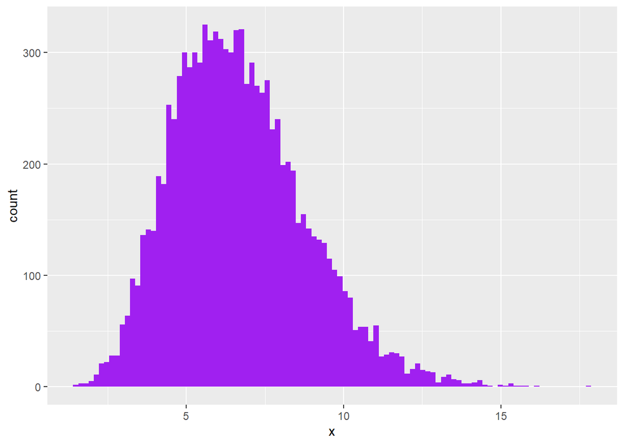

```r
ggplot(tibble(x = rgamma(10000, shape = 10, rate = 3/2)),
   aes(x = x)) + geom_histogram(bins = 100, fill= "purple")
```

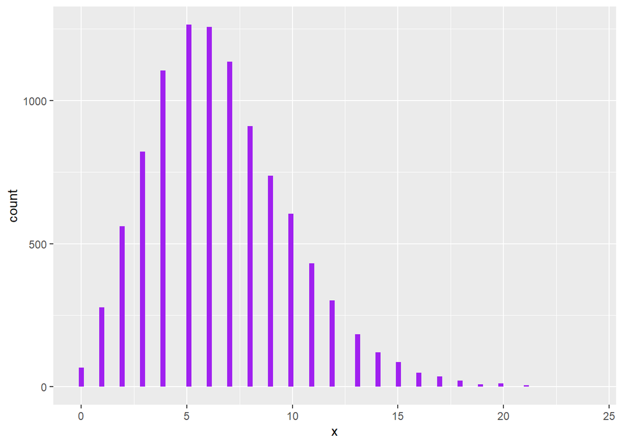

```r
## -----------------------------------------------------------------------------
lambda = rgamma(10000, shape = 10, rate = 3/2)
gp = rpois(length(lambda), lambda = lambda)
ggplot(tibble(x = gp), aes(x = x)) +
  geom_histogram(bins = 100, fill= "purple")
```

```r
## -----------------------------------------------------------------------------
library("vcd")
```

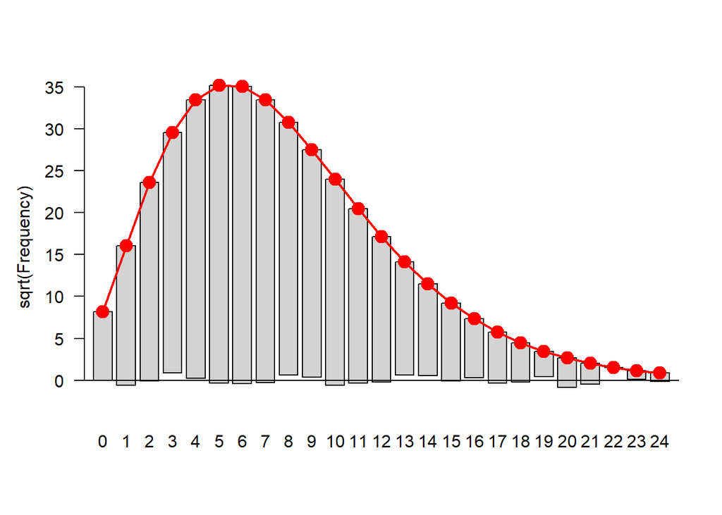

```r
ofit = goodfit(gp, "nbinomial")
plot(ofit, xlab = "")
```

```r
ofit$par
```

```
## $size
## [1] 9.453075
##
## $prob
## [1] 0.5882299
```

```r
## -----------------------------------------------------------------------------
x    = 0:95
mu   = 50
vtot = 80
v1   = vtot - mu
scale = v1/mu    # 0.6
shape = mu^2/v1  # 83.3
p1   = dgamma(x = x, scale = 0.6, shape = 80)
p2   = dpois(x = x, lambda = mu*1.2)
p3   = dnbinom(x = x, mu = mu, size = mu^2/vtot)
```

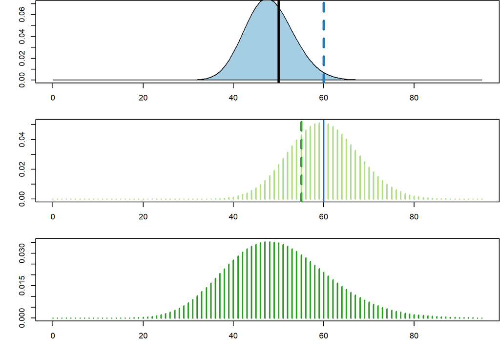

```r
## -----------------------------------------------------------------------------
library("RColorBrewer")
cols = brewer.pal(8, "Paired")
par(mfrow=c(3,1), mai=c(0.5, 0.5, 0.01, 0.01))
xlim = x[c(1, length(x))]
plot(NA, NA, xlim=xlim, ylim=c(0,0.07), type="n", ylab="", xlab="")
polygon(x, p1, col=cols[1])
abline(v=mu, col="black", lwd=3)
abline(v=mu*1.2, col=cols[2], lty=2, lwd=3)
plot(x, p2, col=cols[3], xlim=xlim, ylab="", xlab="", type="h", lwd=2)
abline(v=mu*1.2, col=cols[2], lwd=2)
abline(v=mu*1.1, col=cols[4], lty=2, lwd=3)
plot(x, p3, col=cols[4], xlim=xlim, type="h", lwd=2, ylab="", xlab="")
```

```r
## -----------------------------------------------------------------------------
lambdas = seq(100, 900, by = 100)
simdat = lapply(lambdas, function(l)
    tibble(y = rpois(n = 40, lambda=l), lambda = l)
  ) %>% bind_rows
simdat
```

```
## # A tibble: 360 × 2
##        y lambda
##    <int>  <dbl>
##  1    92    100
##  2   105    100
##  3    97    100
##  4    84    100
##  5   110    100
##  6    95    100
##  7   116    100
##  8   107    100
##  9    95    100
## 10   106    100
## # … with 350 more rows
```

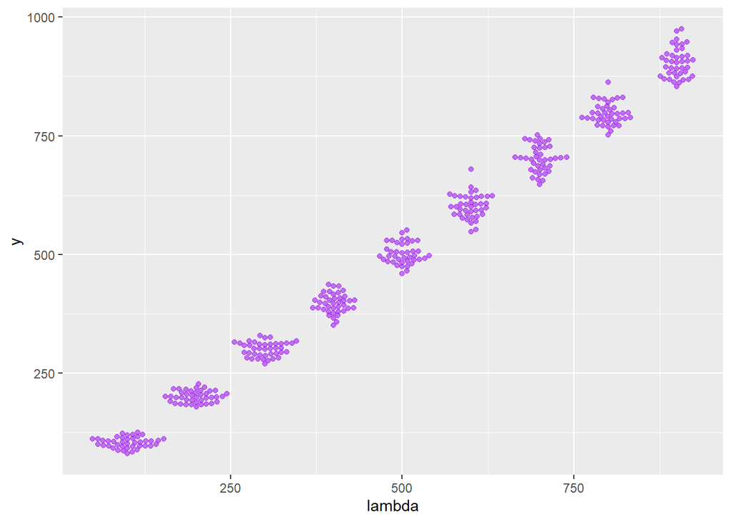

```r
library("ggbeeswarm")
ggplot(simdat, aes(x = lambda, y = y)) +
  geom_beeswarm(alpha = 0.6, color = "purple")
```

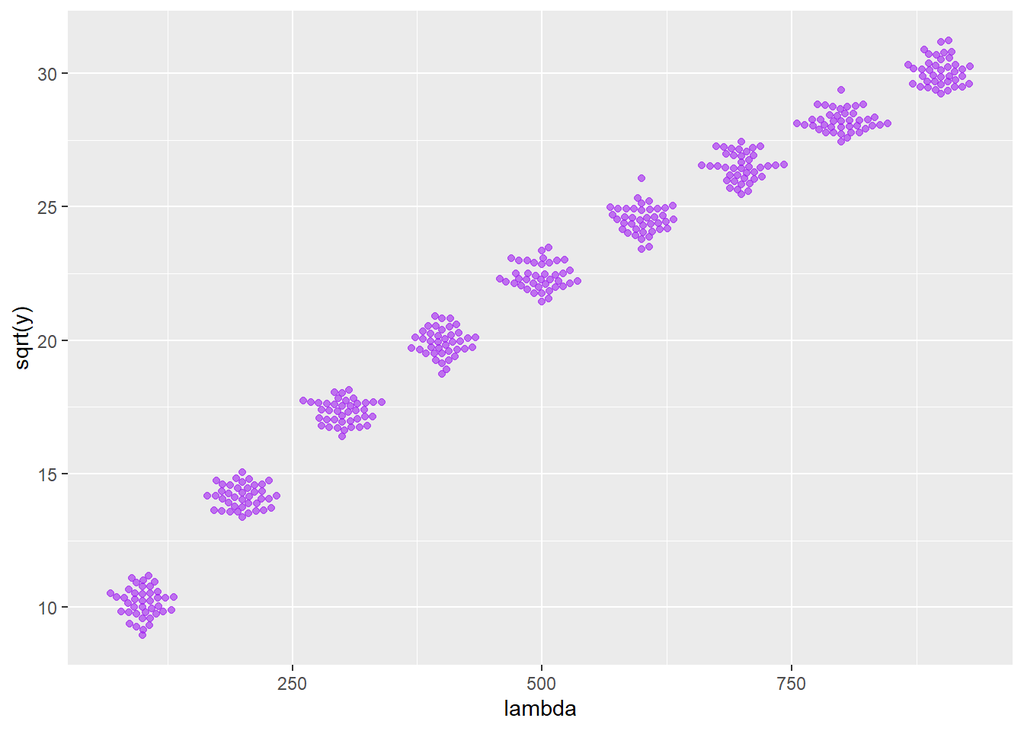

```r
ggplot(simdat, aes(x = lambda, y = sqrt(y))) +
  geom_beeswarm(alpha = 0.6, color = "purple")
```

[Expected Value of Square Root of Poisson Random Variable](https://math.stackexchange.com/questions/1536459/expected-value-of-square-root-of-poisson-random-variable)

In general, for smooth $g(X)$ you can do a Taylor expansion around the mean $\mu=E(X)$ :

$$g(X)=g(\mu)+g′(\mu)(X−\mu)+\frac{g′′(\mu)}{2!}(X−\mu)^2+\frac{g′′′(\mu)}{3!}(X−\mu)^3+⋯$$
So

$$E[g(X)]=g(\mu)+\frac{g′′(\mu)}{2!}m_2+\frac{g′′′(\mu)}{3!}m_3+⋯$$
where $m_i$ is the $i^{th}$ centered moment. In our case $m_2=m_3=\lambda$, so:

$$E[g(X)]=\sqrt{\lambda}−\frac{\lambda^{−1/2}}{8}+\frac{\lambda^{−3/2}}{16}+⋯$$
This approximation is useful only if $\lambda \gg 1$

The mean and variance of any Poisson process is given as

$$E[P(\lambda_i)] = Var[P(\lambda_i)] =
\lambda_i$$

[Square root transformation of Poisson process](https://stats.stackexchange.com/questions/505298/square-root-transformation-of-poisson-process-how-small-var-sqrtp-lambda)

$$\operatorname{var}(\sqrt{P(\lambda)})=E[P(\lambda)]-E[\sqrt{P(\lambda)}]^2=\lambda-E[\sqrt{P(\lambda)}]^2$$

The second term can be approximated *better* as follows:

$$E[\sqrt{P(\lambda)}]\approx
\sqrt{\lambda}-\frac{\lambda^{-1/2}}{8}+\frac{\lambda^{-3/2}}{16}+...$$

Which is why the expected value is also approximated by $\sqrt \lambda$. Square of it will be
$$E[\sqrt{P(\lambda)}]^2\approx \lambda
-\frac{1}{4}+\frac{9}{64\lambda}+...$$

So, the variance will be approximately
$$\operatorname{var}(\sqrt{P(\lambda)})\approx
\frac{1}{4}-\frac{9}{64\lambda}+...$$

which is approximately $1/4$ for large $\lambda$, and the standard deviation is approximately $1/2$.

```r
## -----------------------------------------------------------------------------
.o = options(digits = 3)
summarise(group_by(simdat, lambda), sd(y), sd(2*sqrt(y)))
```

```
## # A tibble: 9 × 3
##   lambda `sd(y)` `sd(2 * sqrt(y))`
##    <dbl>   <dbl>             <dbl>
## 1    100    11.2             1.11
## 2    200    12.2             0.863
## 3    300    15.3             0.884
## 4    400    20.3             1.02
## 5    500    21.9             0.975
## 6    600    25.6             1.04
## 7    700    27.7             1.05
## 8    800    22.9             0.809
## 9    900    31.0             1.03
```

```r
options(.o)
```

```r
## -----------------------------------------------------------------------------
muvalues = 2^seq(0, 10, by = 1)
simgp = lapply(muvalues, function(mu) {
  u = rnbinom(n = 1e4, mu = mu, size = 4) # size:   target for number of successful trials, or dispersion parameter (the shape parameter of the gamma mixing distribution). Must be strictly positive, need not be integer.
  tibble(mean = mean(u), sd = sd(u),
         lower = quantile(u, 0.025),
         upper = quantile(u, 0.975),
         mu = mu)
  } ) %>% bind_rows
simgp
```

```
## # A tibble: 11 × 5
##       mean     sd lower upper    mu
##      <dbl>  <dbl> <dbl> <dbl> <dbl>
##  1    1.01   1.13    0     4      1
##  2    2.01   1.74    0     6      2
##  3    3.99   2.82    0    11      4
##  4    8.05   4.90    1    20      8
##  5   16.1    9.04    3    38     16
##  6   31.9   17.0     7    73     32
##  7   64.0   32.9    17   143     64
##  8  128.    64.0    34   280    128
##  9  255.   128.     69   562.   256
## 10  512.   255.    140  1114.   512
## 11 1029.   511.    274. 2215   1024
```

```r
head(as.data.frame(simgp), 2)
```

```
##     mean       sd lower upper mu
## 1 1.0097 1.128775     0     4  1
## 2 2.0112 1.742808     0     6  2
```

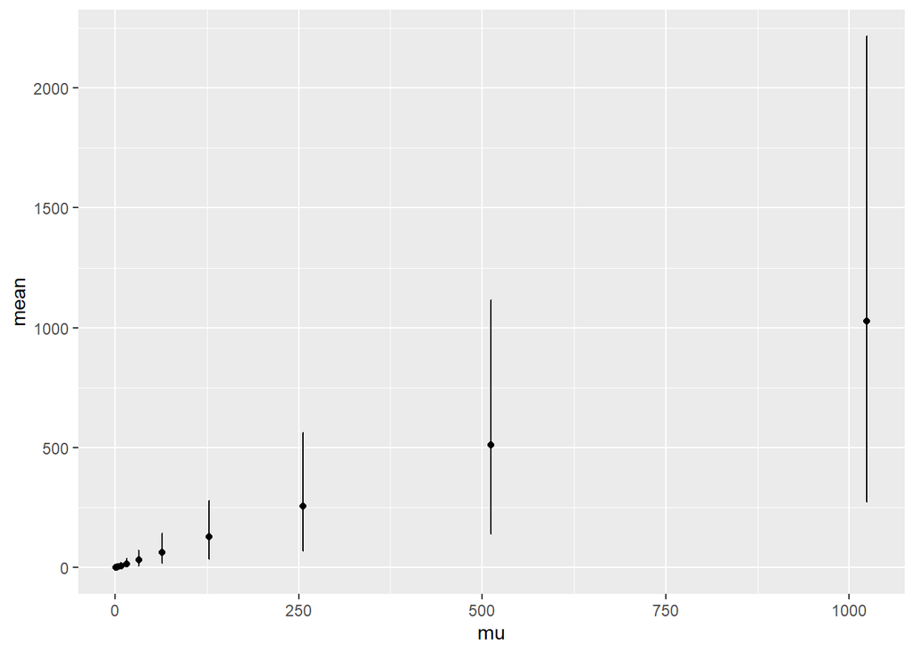

```r
ggplot(simgp, aes(x = mu, y = mean, ymin = lower, ymax = upper)) +
  geom_point() + geom_errorbar()
```

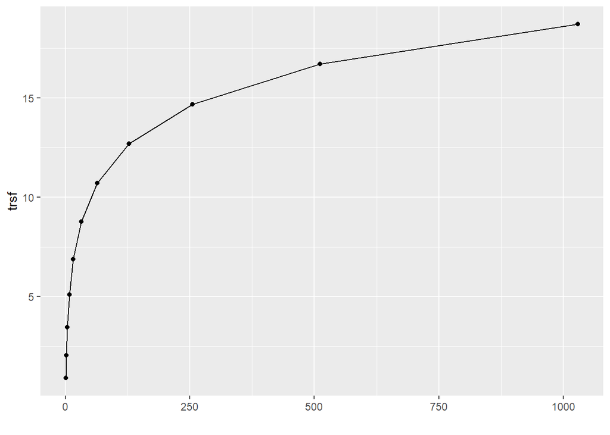

```r
## -----------------------------------------------------------------------------
simgp = mutate(simgp,
  slopes = 1 / sd,
  trsf   = cumsum(slopes * mean))
ggplot(simgp, aes(x = mean, y = trsf)) +
  geom_point() + geom_line() + xlab("")
```

Call our transformation function $g$, and assume it’s differentiable. Also call our random variables $X_i$ , with means $\mu_i$ and variances $v_i$ , and we assume that $\mu_i$ and $v_i$ are related by a functional relationship $v_i = \nu(\mu_i)$ . Then, for values of $X_i$ in the neighborhood of its mean $\mu_i$,
$$g(X_i)=g(\mu_i)+g'(\mu_i)(X_i-\mu_i)+\cdots$$

> - if $\nu(\mu)=\mu$(Poisson), we recover $g(x)=\sqrt{x}$, the square root transformation.
> - If $\nu(\mu)=\alpha \mu^2$, solving the differential equation
>   $$g'(x)=\frac{1}{\sqrt{\nu(x)}}$$
>   gives $g(x)=\log(x)$. This explains why the logarithm transformation is so popular in many data analysis applications: it acts as a variance stabilizing transformation whenever the data have a constant coefficient of variation, that is, when the standard deviation is proportional to the mean.

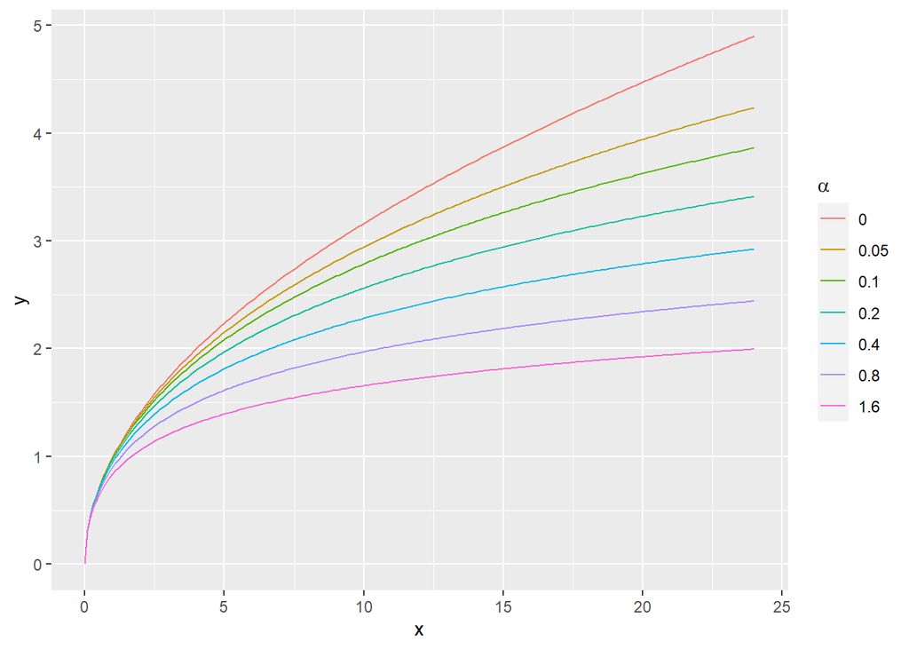

```r
## -----------------------------------------------------------------------------
f = function(x, a)
  ifelse (a==0,
    sqrt(x),
    log(2*sqrt(a) * sqrt(x*(a*x+1)) + 2*a*x+1) / (2*sqrt(a)))
x  = seq(0, 24, by = 0.1)
df = lapply(c(0, 0.05*2^(0:5)), function(a)
  tibble(x = x, a = a, y = f(x, a))) %>% bind_rows()
ggplot(df, aes(x = x, y = y, col = factor(a))) +
  geom_line() + labs(col = expression(alpha))
```

```r
## -----------------------------------------------------------------------------
f2 = function(x, a) ifelse (a==0, sqrt(x), acosh(2*a*x + 1) / (2*sqrt(a)))
with(df, max(abs(f2(x,a) - y)))
```

```
## [1] 8.881784e-16
```

```r
stopifnot(with(df, max(abs(f2(x,a) - y))) < 1e-10)
```

```r
## -----------------------------------------------------------------------------
a = c(0.2, 0.5, 1)
f(1e6, a)
```

```
## [1] 15.196731 10.259171  7.600903
```

```r
1/(2*sqrt(a)) * (log(1e6) + log(4*a))
```

```
## [1] 15.196728 10.259170  7.600902
```

```r
## -----------------------------------------------------------------------------
mx = readRDS("../data/Myst.rds")$yvar
str(mx)
```

```
##  num [1:1800] 0.3038 0.0596 -0.0204 0.1849 0.2842 ...
```

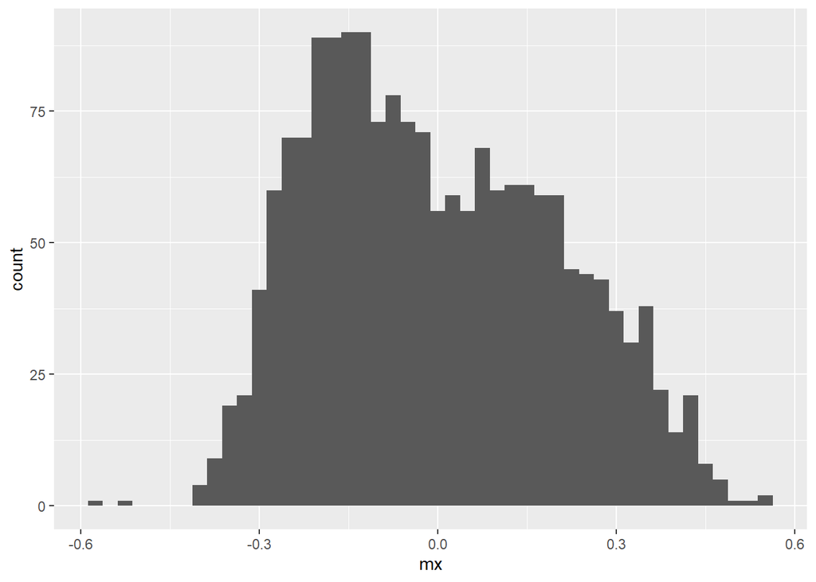

```r
ggplot(tibble(mx), aes(x = mx)) + geom_histogram(binwidth = 0.025)
```

```r
## -----------------------------------------------------------------------------
wA = runif(length(mx))
wB = 1 - wA

## -----------------------------------------------------------------------------
iter      = 0
loglik    = -Inf
delta     = +Inf
tolerance = 1e-3
miniter   = 50
maxiter   = 1000
```

```r
## -----------------------------------------------------------------------------
while((delta > tolerance) && (iter <= maxiter) || (iter < miniter)) {
  lambda = mean(wA)
  muA = weighted.mean(mx, wA)
  muB = weighted.mean(mx, wB)
  sdA = sqrt(weighted.mean((mx - muA)^2, wA))
  sdB = sqrt(weighted.mean((mx - muB)^2, wB))

  pA   =    lambda    * dnorm(mx, mean = muA, sd = sdA)
  pB   = (1 - lambda) * dnorm(mx, mean = muB, sd = sdB)
  ptot = pA + pB
  wA   = pA / ptot
  wB   = pB / ptot

  loglikOld = loglik
  loglik = sum(log(pA)) + sum(log(pB))
  delta = abs(loglikOld - loglik)
  iter = iter + 1
}
iter
```

```
## [1] 327
```

```r
## -----------------------------------------------------------------------------
.o = options(digits = 3)
c(lambda, muA, muB, sdA, sdB)
```

```
## [1]  0.5244  0.1473 -0.1694  0.1498  0.0983
```

```r
options(.o)

## -----------------------------------------------------------------------------
.o = options(digits = 3)
gm = mixtools::normalmixEM(mx, k = 2)
```

```
## number of iterations= 292
```

```r
with(gm, c(lambda[1], mu, sigma))
```

```
## [1]  0.4756 -0.1694  0.1473  0.0983  0.1498
```

```r
options(.o)
```

```r
## -----------------------------------------------------------------------------
library("flexmix")
```

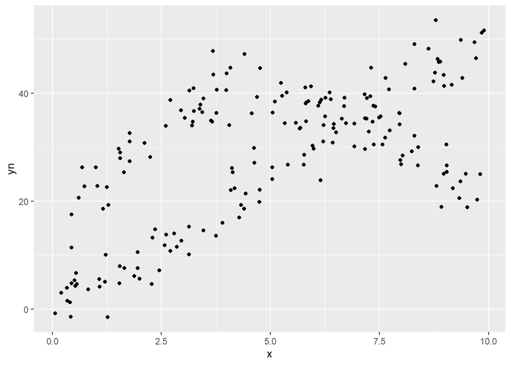

```r
data("NPreg")

## -----------------------------------------------------------------------------
m1 = flexmix(yn ~ x + I(x^2), data = NPreg, k = 2)

## -----------------------------------------------------------------------------
ggplot(NPreg, aes(x = x, y = yn)) + geom_point()
```

```r
## -----------------------------------------------------------------------------
modeltools::parameters(m1, component = 1)
```

```
##                      Comp.1
## coef.(Intercept) 14.7173366
## coef.x            9.8464235
## coef.I(x^2)      -0.9683323
## sigma             3.4797618
```

```r
modeltools::parameters(m1, component = 2)
```

```
##                      Comp.2
## coef.(Intercept) -0.2093152
## coef.x            4.8174417
## coef.I(x^2)       0.0361905
## sigma             3.4763206
```

```r
## -----------------------------------------------------------------------------
table(NPreg$class, modeltools::clusters(m1))
```

```
##
##      1  2
##   1  5 95
##   2 95  5
```

```r
## -----------------------------------------------------------------------------
summary(m1)
```

```
##
## Call:
## flexmix(formula = yn ~ x + I(x^2), data = NPreg, k = 2)
##
##        prior size post>0 ratio
## Comp.1 0.506  100    141 0.709
## Comp.2 0.494  100    145 0.690
##
## 'log Lik.' -642.5453 (df=9)
## AIC: 1303.091   BIC: 1332.775
```

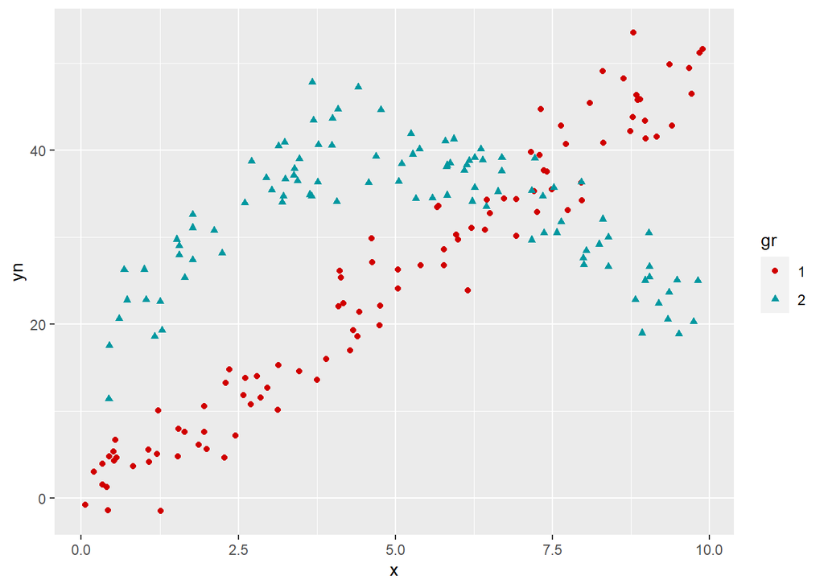

```r
## -----------------------------------------------------------------------------
NPreg = mutate(NPreg, gr = factor(class))
ggplot(NPreg, aes(x = x, y = yn, group = gr)) +
   geom_point(aes(colour = gr, shape = gr)) +
   scale_colour_hue(l = 40, c = 180)
```